# Webappendix for the paper entitled On evaluating how well a biomarker can predict treatment response with survival data

Bassirou

2/12/2018

This document makes an easier access to the supplementary material of the papier entitled **On evaluating how well a biomarker can predict treatment response with survival data**.

## 1) Datasets

We use two datasets in the applications. First get [JBR.10 data set](https://www.ncbi.nlm.nih.gov/geo/query/acc.cgi?acc=gse14814), we are interested in these datasets four variables.

- Os_time : vector of observed failure times.
- Os_status: vector of indicator of status (0 for censoring, 1 for type of event).
- Treat :vector of treatment indicator 1 if treated and 0 others.
- Marker : vector of continuous biomarker values

```r
load("~/Desktop/article_new/JBR.10_data.RData")
head(JBR.10_data)
```

```
##           OS_time OS_status  AGE   SEXE Treat     Marquer Marquer_cat
## GSM370913    8.52         0 44.9 Female     0  -0.1662528           H
## GSM370914    9.03         0 53.4   Male     0 -11.3946353           L
## GSM370915    1.32         1 64.1   Male     1 -31.3685288           L
## GSM370916    8.66         0 57.1   Male     1 -61.3106530           L
## GSM370917    8.23         0 65.7 Female     1 -35.8740573           L
## GSM370918    2.06         1 69.2   Male     0 -35.5725421           L
```

and [csl data set](http://publicifsv.sund.ku.dk/~linearpredictors/?page=datasets&dataset=Csl). The following variables interested are :

- years : vector of observed failure times.
- dc: vector of indicator of status (0 for censoring, 1 died).
- tment: vector of treatment indicator 1 if treated and 0 others.
- pro : vector of continuous biomarker values

```r
load("~/Desktop/article_new/csl_data.RData")
head(csl_data)
```

```
##    id dc days tment sex asc age pro ace infl      years
## 1 204  1    4     1   1   2  66  50 126    2 0.01095140
## 2 374  1    5     1   0   2  66  43  80    1 0.01368925
## 3 184  1   13     0   1   2  57  43 110    0 0.03559206
## 4  60  1   16     0   0   2  67  40 158    2 0.04380561
## 5 449  1   21     0   1   2  62  25 120    2 0.05749487
## 6 224  0   22     1   0   0  75  94 327    1 0.06023272
```

## 2) Check treatment effect

This function display four graphics of the coefficients of the models. This function help to test graphically if the coefficients in the models are time-varying.

```r
library(timereg)
```

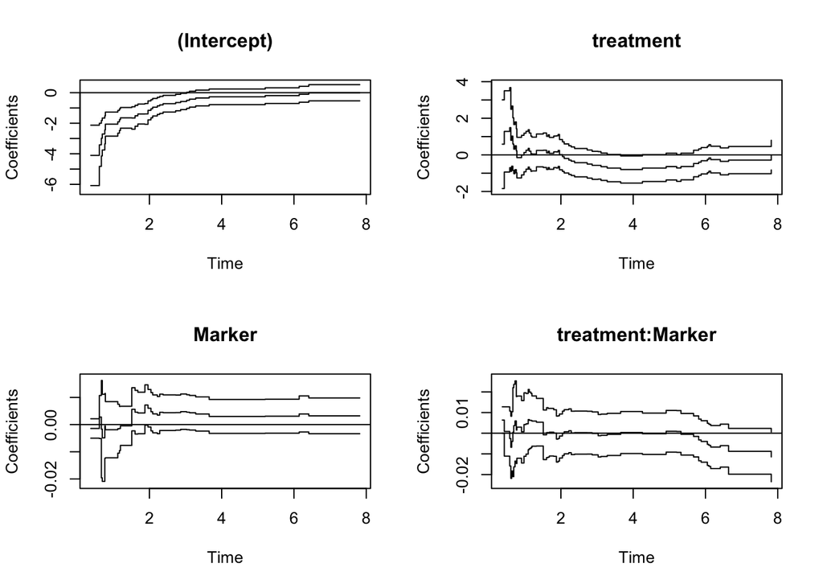

```r
Check_effect <- function(time,event,treatment,Marker){
  data <- cbind.data.frame(time=time,event=event,treatment=treatment,Marker=Marker)
estim <- timereg::comp.risk(Event(time,event)~treatment+Marker+
              treatment*Marker,
            cause=1,
            data=data,
            resample.iid=1,
            n.sim=1000,
            model="logistic")
 par(mfrow=c(2,2))
plot(estim)
}

Check_effect(JBR.10_data$OS_time,JBR.10_data$OS_status,JBR.10_data$Treat,
            JBR.10_data$Marquer)
```

## 3) Standard decision

We provide a function get.censoring.weights to estimated the inverse probability of censoring weighting.

```r
library(prodlim)
get.censoring.weights <- function(timepoint,time,event){
  untreated <- time >= timepoint
  censure <- time < timepoint & event==0
  new.times <- time
  Fitcens <- prodlim(Hist(time,event)~1,reverse=TRUE)
  new.times [untreated] <- timepoint
  ## increasing time
  times_sorted <- sort(new.times,decreasing=FALSE,method='shell')
  order <- rank(new.times)
  weights <- predict(Fitcens,times=times_sorted)[order]
  weights <- 1/weights
  weights[censure] <- 0
  return(weights)
}
##}}}

##{{{
## Exemple
w <- rep(0,length(JBR.10_data$OS_time))
timepoint <- 2
# weigtght in untreated subjects
w[JBR.10_data$Treat==0] <- get.censoring.weights(timepoint,JBR.10_data$OS_time[JBR.10_data$Treat==0],JBR.10_data$OS_status[JBR.10_data$Treat==0])
# rho_0(t)
rho_0 <- sum(w*I(JBR.10_data$OS_time<timepoint)*(1-JBR.10_data$Treat))/sum(w*(1-JBR.10_data$Treat))
round(rho_0,2)
```

```
## [1] 0.26
```

```r
##}}}

##{{{
w <- rep(0,length(JBR.10_data$OS_time))
w[JBR.10_data$Treat==1] <- get.censoring.weights(timepoint,JBR.10_data$OS_time[JBR.10_data$Treat==1],JBR.10_data$OS_status[JBR.10_data$Treat==1])
# rho_1(t)
rho_1 <- sum(w*I(JBR.10_data$OS_time<timepoint)*JBR.10_data$Treat)/sum(w*JBR.10_data$Treat)

round(rho_1,2)
```

```
## [1] 0.24
```

```r
##}}}
```

## 4) Get risk in treated and untreated subjects

This function provides a dataframe of two vector risk_0 in untreated subjects and risk_1 in treated subjects.

```r
get_risk <- function(time,event,Treat,Marker,varying,timepoint)
  {
  if (length(event)!=length(time) | length(Marker)!=length(time)|length(Treat)!=length(time) | length(event)!=length(time)){
    stop("lengths of vector time, event,treatment and Marker have to be equal\n") }
  if (missing(timepoint)){
    stop("Choose one time for horizon prediction \n") }

  data <- cbind.data.frame(time=time,event=event,Treat=Treat,Marker=Marker)

  if(varying==TRUE){

      estim <- comp.risk(Event(time,event)~Treat+const(Marker)+
                          const(Treat*Marker),
                         cause=1,
                         data=data,
                         times=timepoint,
                         resample.iid=1,
                         n.sim=1000,
                         model="logistic")
                                     }
   if(varying==FALSE || missing(varying)) {
      estim <- comp.risk(Event(time,event)~const(Treat)+const(Marker)+
                           const(Treat*Marker),
                         cause=1,
                         data=data,
                         resample.iid=1,
                         times=timepoint,
                         n.sim=1000,
                         model="logistic")
                                        }

  predittreat1 <- predict(estim,newdata=data.frame(Marker=sort(Marker),Treat=1),
                          n.sim=1,times=timepoint)$P1
  predittreat0<- predict(estim,newdata=data.frame(Marker=sort(Marker),Treat=0),
                         n.sim=1,times=timepoint)$P1

risk <- cbind.data.frame(risk_0=predittreat0,risk_1=predittreat1)
return(risk)
}
```

## Example

```r
risk1 <- get_risk(csl_data$years,csl_data$dc,csl_data$tment,
                      csl_data$pro,varying=TRUE,2)
risk2 <- get_risk(JBR.10_data$OS_time,JBR.10_data$OS_status,JBR.10_data$Treat,JBR.10_data$Marquer,varying=TRUE,2)
head(risk1)
```

```
##      risk_0    risk_1
## 1 0.6123317 0.7325829
## 2 0.5914443 0.7060135
## 3 0.5595071 0.6634265
## 4 0.5541284 0.6560374
## 5 0.5487371 0.6485720
## 6 0.5487371 0.6485720
```

## 5) plot time-dependent marker by treatment predictiveness curves

This function displays the time-dependent marker by treatment predictiveness curves.

```r
plotime_predictiveness_curve <- function(Objets,timepoint,Marker){
xlim <- c(0,100)
breaks = seq(xlim[1], xlim[2], length.out = 5)
k <- length(Objets$risk_0)
x1<- sort(Marker)
y1 <- (((1:k)*100)/k)
z1 <- Objets$risk_0
z2 <- Objets$risk_1
plot(y1,z1,type='l',col="red",xlab="(%)population \n marker Value",ylab="Risk given marker (%)",
     main=paste("Time dependent marker-by-treatment \n predictiveness curve at times t=",timepoint,"years"),ylim=c(0,1),axes=FALSE)
lines(y1,z2,type='l',col="blue",lwd=2)
axis(1)
axis(2,at=seq(from=0,to=1,by=0.2),labels=seq(from=0,to=1,by=0.2)*100,las=2)
axis(1,at= breaks, label = round(quantile(x1, prob = breaks/100), 1),pos=-0.26)
}
```

## Example

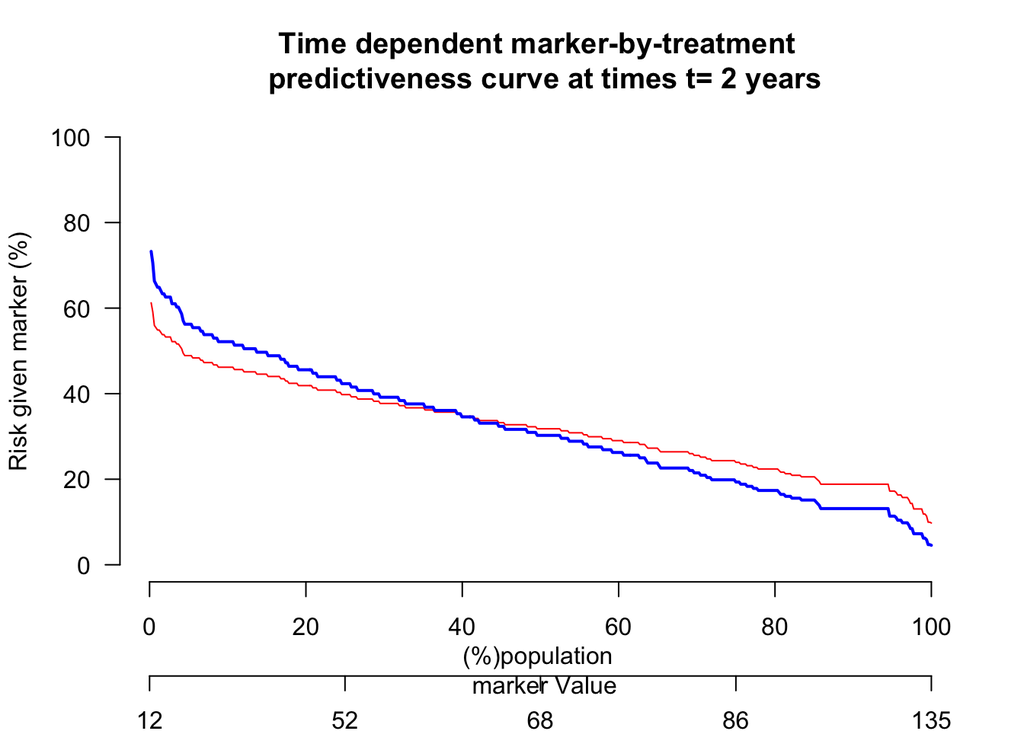

```r
plotime_predictiveness_curve(Objets=risk1,timepoint=2,Marker=csl_data$pro)
```

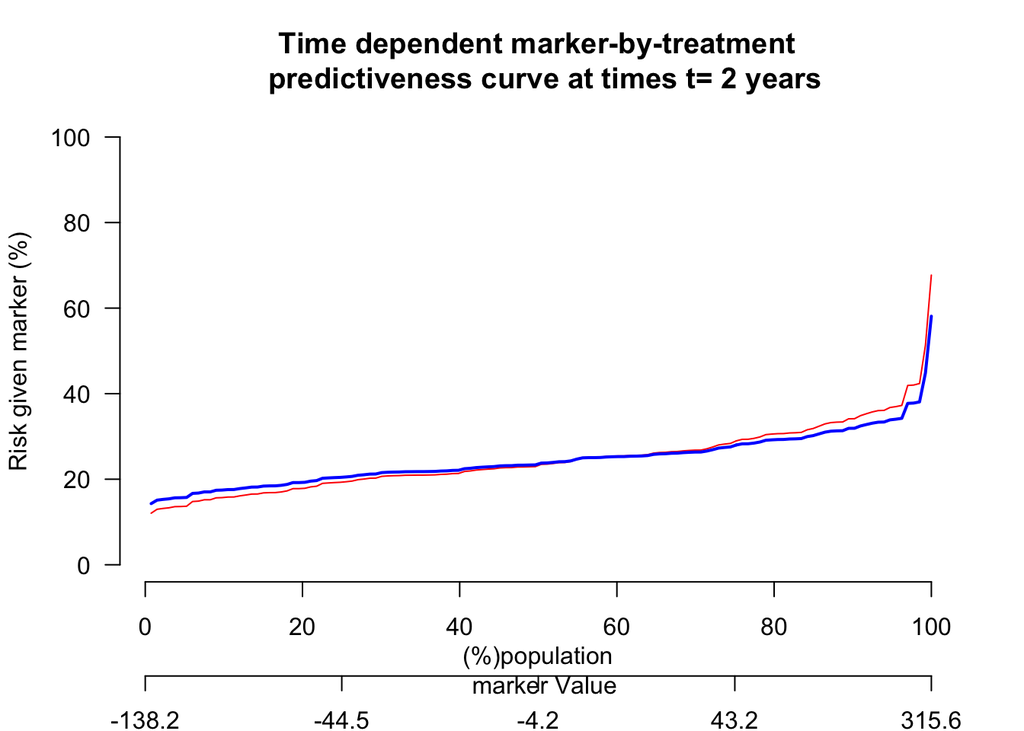

```r
plotime_predictiveness_curve(Objets=risk2,timepoint=2,Marker=JBR.10_data$Marquer)
```

## 6) Get optimal threshold

```r
library(boot)
marker_value <- function(formula,data,indices){
    d=data[indices,]
    estim <- comp.risk(formula,data=d, cause=1,
                       resample.iid=1,
                       times=timepoint,
                       n.sim =1000,
                       model="logistic")
     out <- -estim$cum[3]/estim$gamma[2]
 if (out >= min(d$Marquer) && out <= max(d$Marquer))
           return(out)
                 else
          return(NA)
}
```

## 6-a) JBR.10_data

```r
result1 <- boot(data=JBR.10_data,statistic=marker_value,R=999,
                formula=Event(OS_time,OS_status)~Treat+const(Marquer)+
                  const(Treat*Marquer))
ci1 <- boot.ci(result1,conf=0.95, type="norm")

paste(result1$t0,"(", ci1$normal[2],",",ci1$normal[3],")")
```

```
## [1] "7.87787936289058 ( -179.00197607626 , 159.893343253296 )"
```

## 6-b) Csl_data

```r
csl_data$Marquer <- csl_data$pro
result2 <- boot(data=csl_data,statistic=marker_value,R=999,
                formula=Event(years,dc)~tment+const(pro)+
                  const(tment*pro))
ci2 <- boot.ci(result2,conf=0.95, type="norm")

paste(result2$t0,"(", ci2$normal[2],",",ci2$normal[3],")")
```

```
## [1] "61.5169498022851 ( 22.4961066011994 , 97.2801060091349 )"
```

There is a very wide confidence interval because of the small sample size.

## 7) Data extension

```r
library(survival)
set.seed(1234)
d <- JBR.10_data

## {{{ sample size
n <- 5000
timepoints <- c(2,6) # give in increasing order !!
## }}}

## {{{ estimate the model from the data
estima <- comp.risk(Event(OS_time,OS_status)~Treat+const(Marquer)+
                      const(Treat*Marquer),
                    data=d,
                    cause=1,
                    times=timepoints,
                    resample.iid=1,
                    n.sim=1000,
                    model="logistic")
## }}}

## {{{ generate biomarker
Y <- sample(x=d$Marquer, size=n, replace=TRUE)
# This is equivalent to generate the values by inverting the empirical cumulative distribution function.
# Indeed, in both case, each new value is drwan among values of d$Marquer, with probability 1*/nrow(d)
## }}}

## {{{ generate treatment
treat <- rbinom(n,size=1,prob=0.5)
## }}}

## {{{ generate time to event

## {{{ first generate the risk given marker and treatment at each time point
RiskGivenYTreat <- function(x){
  predict(estima,newdata = data.frame(Marquer=x[1],Treat=x[2]),times=timepoints)$P1
}
AllRisks <- t(apply(cbind(Y,treat),1,RiskGivenYTreat))
colnames(AllRisks) <- paste0("Risk at t=",timepoints)
head(AllRisks)
```

```
##      Risk at t=2 Risk at t=6
## [1,]   0.2485798   0.3842139
## [2,]   0.2733079   0.4800076
## [3,]   0.2188104   0.3456736
## [4,]   0.2591523   0.4619519
## [5,]   0.2624842   0.4662502
## [6,]   0.2389415   0.4352164
```

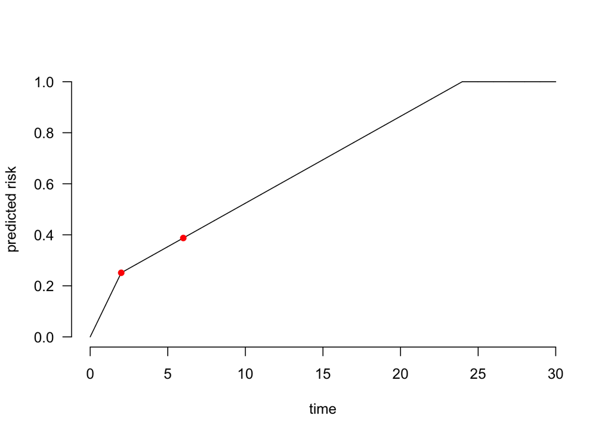

```r
## }}}

## {{{ Second, create a function which linearly extrapolates between the time points, to get the risk for any time
ExtrapolatedRisk <- function(t,allRisk,timepoints){
  if(t<timepoints[1]){
    out <- t*allRisk[1]/timepoints[1]
  }else{
    i <- sum(t>=timepoints)
    if(i<length(timepoints)){
      a <-  allRisk[i]
      b <- (allRisk[i+1]-allRisk[i])/(timepoints[i+1]-timepoints[i])
      if(b==0){b <- 0.001} # we need to force the risk to be increasing, to avoid computational issue
      out <- a + b*(t-timepoints[i])
    }else{
      a <-  allRisk[i-1]
      b <- (allRisk[i]-allRisk[i-1])/(timepoints[i]-timepoints[i-1])
      out <- a + b*(t-timepoints[i-1])
    }
  }
  min(out,1)
}

# example of the curve of predicted risk given marker and treatment
whichSubject <- 30
ttt <- seq(from=0,to=30,by=0.01)
yyy <- sapply(ttt,function(x){ExtrapolatedRisk(x,AllRisks[whichSubject,],timepoints)})
plot(ttt,yyy,type="l",ylab="predicted risk", xlab="time", axes=FALSE)
points(timepoints,AllRisks[whichSubject,], col="red", pch=16)
axis(1)
axis(2,las=1)
```

```r
## }}}

## {{{ Generate time to event
Temps <- rep(NA,n)
U <- runif(n)
for(i in 1:n){
  Temps[i] <- uniroot(f=function(t)(ExtrapolatedRisk(t,AllRisks[i,],timepoints)-U[i]),
                      lower=0,
                      upper=1000,
                      tol=0.0001)$root
}
# note: actually we do not really need to use uniroot in that case, because we can find a simple formula
# for the root of the equation (as it is piecewise linear).
## }}}


## }}}


## {{{ generate censoring time
AllTimeCens <- unique(sort(d$OS_time[d$OS_status==0]))
FitCens <- prodlim(Hist(OS_time,OS_status)~1,data=d,reverse=TRUE)
survCens <- predict(FitCens,times=AllTimeCens)
Jumps <- -diff(c(1,survCens,0))
head(cbind(c(AllTimeCens,max(d$OS_time)+1),Jumps))
```

```
##                Jumps
## [1,] 2.86 0.02150538
## [2,] 3.00 0.01087216
## [3,] 3.24 0.01125142
## [4,] 3.51 0.01125142
## [5,] 3.95 0.01152585
## [6,] 4.03 0.01152585
```

```r
length(AllTimeCens)
```

```
## [1] 68
```

```r
length(Jumps)
```

```
## [1] 69
```

```r
sum(Jumps)
```

```
## [1] 1
```

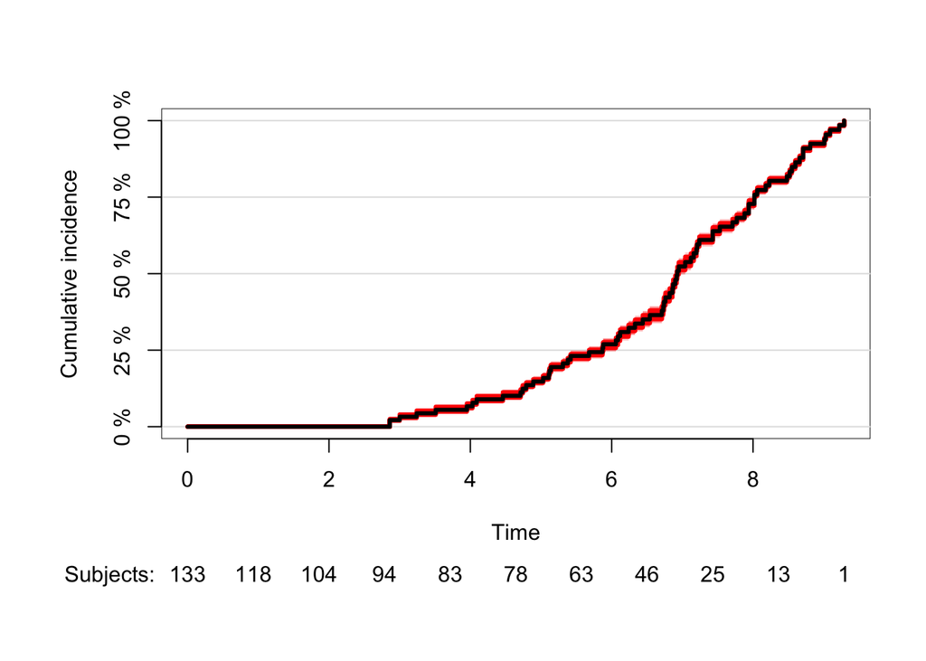

```r
MyTcens <- sample(x=c(AllTimeCens,max(d$OS_time)+1),size=n,replace=TRUE,prob=Jumps)
# the idea is simply that inverting the estimated empirical cumulative distribution function (ecdf) is equivalent to draw censored time, among those observed int the real dataset, whith probability equal to the jump of the Kaplan-Meier estimator of the censoring distribution.
# becase Kaplan-Meier does not always reach 0, I added the time max(d$OS_time)+1 (beyond the last observed time in the data set), which is drawn with prob 1-sum(jumps).


## Just to Check that it works
plot(FitCens,confint=FALSE)
for(i in 1:10){
  Tcens <- sample(x=c(AllTimeCens,max(d$OS_time)+1),size=n,replace=TRUE,prob=Jumps)
  di <- data.frame(time=Tcens,status=rep(0,n))
  plot(prodlim(Hist(time,status)~1,data=di,reverse=TRUE),add=TRUE,col="red")
}
plot(FitCens,add=TRUE,confint=FALSE)
```

```r
## }}}


## {{{ Final simulated data
dataSimul <- data.frame(time=pmin(Temps,MyTcens),
                        status=as.numeric(Temps<=MyTcens),
                        treat=treat,
                        Y=Y)
table(dataSimul$status)
```

```
##
##    0    1
## 2741 2259
```

```r
table(d$OS_status)
```

```
##
##  0  1
## 73 60
```

```r
head(dataSimul)
```

```
##       time status treat         Y
## 1 1.593839      1     1  25.28741
## 2 6.166110      1     0  27.76998
## 3 6.412225      1     1 -99.02291
## 4 1.265456      1     0  11.03747
## 5 5.303040      1     0  15.02750
## 6 8.810000      0     0 -13.92275
```

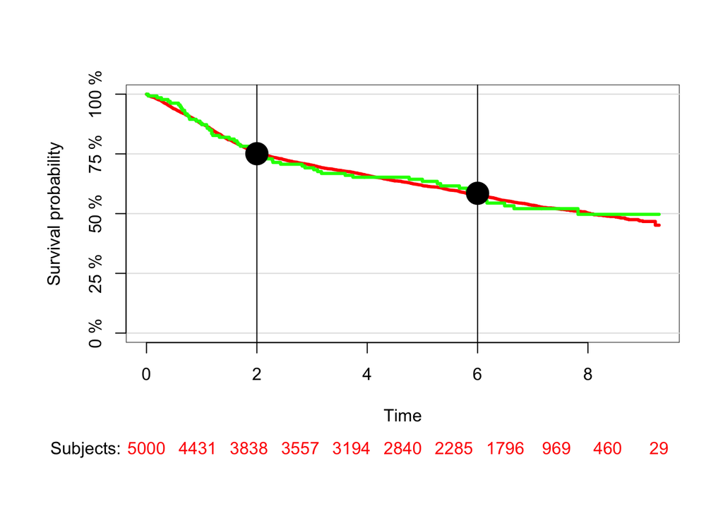

```r
## }}}


## {{{ Check that estimates from simulated data match with those of the data set

## {{{ plot
plot(prodlim(Hist(time,status)~1,data=dataSimul),col="red",confint=FALSE)
plot(prodlim(Hist(OS_time,OS_status)~1,data=d),col="green", add=TRUE,confint=FALSE)
abline(v=timepoints)
points(timepoints,1-colMeans(AllRisks),cex=3,pch=16)
```

```r
# Here the two Kaplan-Meier curve should (approximately) be equal
# at the times corresponding to timepoints
## }}}

## {{{ check values
estima1 <- comp.risk(Event(time,status)~treat+const(Y)+
                       const(treat*Y),
                     data=dataSimul,
                     cause=1,
                     times=timepoints,
                     resample.iid=1,
                     n.sim=5,
                     model="logistic")
estima$cum
```

```
##      time (Intercept)       Treat
## [1,]    2  -1.0981865 -0.04186614
## [2,]    6  -0.2002947 -0.30525738
```

```r
estima1$cum
```

```
##      time (Intercept)       treat
## [1,]    2  -1.1604116  0.08889326
## [2,]    6  -0.2177929 -0.19327892
```

```r
## }}}

## }}}
```

## Check coefficients

```r
##{{{
Tabcheck <- data.frame(beta0=c(estima$cum[2],estima1$cum[2]),
                       beta1=c(estima$cum[3],estima1$cum[3]),
                       beta2=c(coef(estima)[1,"Coef."],coef(estima1)[1,"Coef."]),
                       beta3=c(coef(estima)[2,"Coef."],coef(estima1)[2,"Coef."]))

rownames(Tabcheck) <- c("Coef with real data","coef with Simulated data")

Tabcheck
```

```
##                          beta0     beta1   beta2    beta3
## Coef with real data          6 -1.098186 0.00433 -0.00299
## coef with Simulated data     6 -1.160412 0.00468 -0.00269
```

## 8) After extension JBR.10.data with n=5000

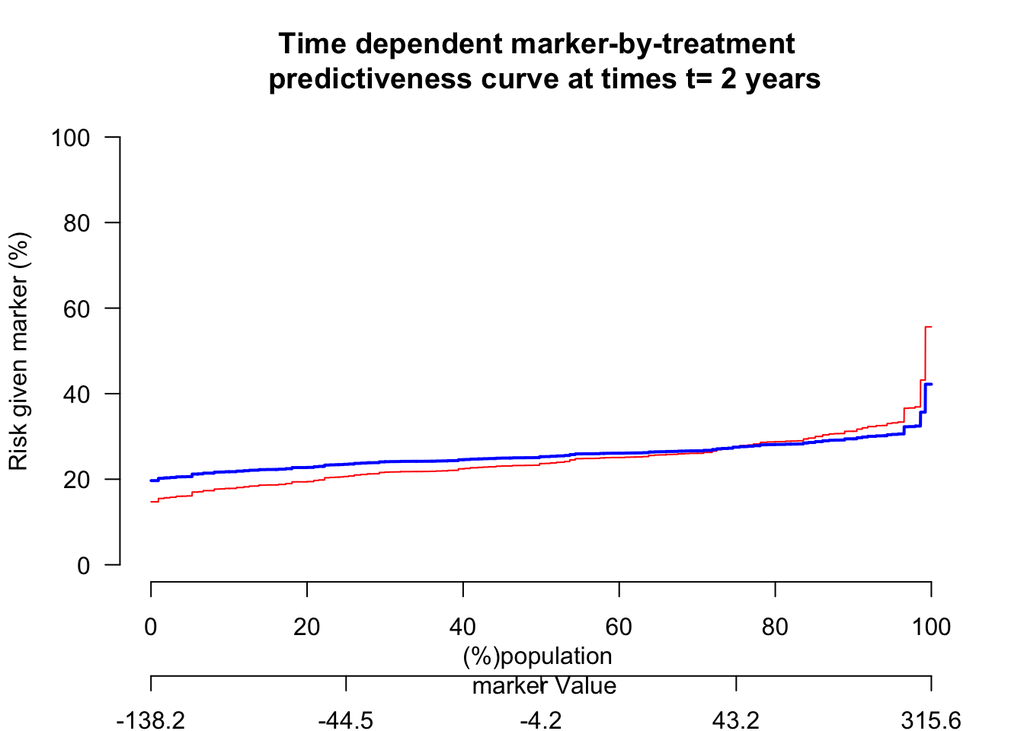

```r
risk3 <- get_risk(dataSimul$time,dataSimul$status,dataSimul$treat,dataSimul$Y,varying=TRUE,2)

plotime_predictiveness_curve(Objets=risk3,timepoint=2,Marker=dataSimul$Y)
```

```r
dataSimul$Marquer <- dataSimul$Y
result3 <- boot(data=dataSimul,statistic=marker_value,R=999,
                formula=Event(time,status)~treat+const(Y)+
                  const(treat*Y))
ci3 <- boot.ci(result3,conf=0.95, type="norm")

paste(result3$t0,"(", ci3$normal[2],",",ci3$normal[3],")")
```

```
## [1] "40.4054330739842 ( -65.157496035746 , 133.611815634089 )"
```

## 9) Data simulations

we use the function below to simulate our datasets using the time-dependent logistic model.

- n: the sample size
- scenario : scenario=1 if you simulate a dataset with constant treatment effect

scenario=2 if treatment effect in the model is increasing with time

scenario=3 if treatment effect in the model is decreasing with time

```r
simuldata <- function(n,scenario) {
# Parametres des simulations
myseed <- 123456 # graine

# coefficients of time-dependent logistic model
beta2 <- 0.6     # coefficients of biomarkerY
beta3 <- -1.5  # interaction between marker and treatment
a <- 10

set.seed(myseed)

Y <- rnorm(n,0,1) # biomarker value
C <- rexp(n,0.2)  # censoring distribution

Treat <- rbinom(n,size=1,prob=0.5) # treatment indicator

# }}}
if(scenario==1){
beta1 <- -0.29
  U <- runif(n)
  Tsur <- a*(U/(1-U))*exp(-(beta1*Treat+beta2*Y+beta3*Treat*Y))
}

if(scenario==2) {
  # piecewice constant treatment effect
   beta1<-function(x,a=-1.24,b=-0.31,seuil=3) # effect of treatment
  {
    return(ifelse(x<=seuil,a,b))
  }

f <- function(x,i){
  prob <-exp(log(x/a)+beta1(x)*Treat[i]+beta2*Y[i]+beta3*Treat[i]*Y[i])/(1+exp(log(x/a)+beta1(x)*Treat[i]+beta2*Y[i]+beta3*Treat[i]*Y[i]))
  return(prob)
}


U <- runif(n)
Tsur <- c()
for(i in 1:n){
  Tsur[i] <- uniroot(function(t)(f(t,i)-U[i]),c(0,15),f.lower=-1,f.upper=1,tol=0.0001)$root
}

}

if(scenario==3){
  beta3 <- -2
  f <- function(x,i){
    prob <-exp(log(x/a)+log(1/(x+1))*Treat[i]+beta2*Y[i]+beta3*Treat[i]*Y[i])/(1+exp(log(x/a)+log(1/(x+1))*Treat[i]+beta2*Y[i]+beta3*Treat[i]*Y[i]))
    return(prob)
  }

  U <- runif(n)
  Tsur <- c()
  for(i in 1:n){
    Tsur[i] <- uniroot(function(t)(f(t,i)-U[i]),c(0,15),f.lower=-1,f.upper=1,tol=0.0001)$root
  }

}

delta <- as.numeric(Tsur<=C)
Tsuiv <- pmin(Tsur,C)

donne<- as.data.frame(cbind(time=Tsuiv,status=delta,Y=Y,Treat=Treat))
return(donne)
}

## exemple
data_1 <- simuldata(n=5000,scenario=1)

data_2 <- simuldata(n=5000,scenario=2)

data_3 <- simuldata(n=5000,scenario=3)

head(data_1)
```

```
##          time status           Y Treat
## 1  5.64574683      0  0.83373317     0
## 2  0.08436632      1 -0.27604777     1
## 3 16.33163370      0 -0.35500184     1
## 4  2.11897264      1  0.08748742     0
## 5  0.05467892      1  2.25225573     0
## 6  0.77481419      0  0.83446013     0
```

```r
head(data_2)
```

```
##          time status           Y Treat
## 1  5.64574683      0  0.83373317     0
## 2  0.21814738      1 -0.27604777     1
## 3 14.99991442      1 -0.35500184     1
## 4  2.11899257      1  0.08748742     0
## 5  0.05467313      1  2.25225573     0
## 6  0.77481419      0  0.83446013     0
```

```r
head(data_3)
```

```
##          time status           Y Treat
## 1  5.64574683      0  0.83373317     0
## 2  0.05819132      1 -0.27604777     1
## 3 14.99993028      1 -0.35500184     1
## 4  2.11899257      1  0.08748742     0
## 5  0.05467313      1  2.25225573     0
## 6  0.77481419      0  0.83446013     0
```